# DM-Practical-02 A - Datawarehouse

### Q1: Data Cube

```python
import pandas as pd
from sqlalchemy import create_engine, text
from sqlalchemy.orm import sessionmaker
from mlxtend.frequent_patterns import apriori, fpgrowth, association_rules
import seaborn as sns
import matplotlib.pyplot as plt
```

```python
df = pd.read_csv('DW_dataset.csv')
```

```python
df['Job Title'] = df['Job Title'].str.strip()
df['Gender'] = df['Gender'].str.strip()
df[['Address', 'County']] = df["Address"].str.split(r"\bCo\b", expand=True)
df['County'] = df['County'].str.replace(r'.', "", regex=True)
df['Date of Birth'] = pd.to_datetime(df['Date of Birth'], infer_datetime_format=True)
df['Date Joined'] = pd.to_datetime(df['Date Joined'], infer_datetime_format=True)
df['Date Left'] = pd.to_datetime(df['Date Left'], infer_datetime_format=True)


def getJobCategory(x):
    y = x.split(' ')
    if 'Technician' in y:
        return 'Technical'
    elif 'Director' in y:
        return 'Management'
    elif 'Manager' in y:
        return 'Management'

df['Job Category'] = df["Job Title"].apply(getJobCategory)
df = df.drop(['Address', 'Job Title'], axis=1)
```

```python
# Creating - PSQL database and engine
engine = create_engine('postgresql://postgres:root@localhost:5432/postgres')

# Storing DataFrame-df into PSQL database
df.to_sql('employee_data', engine, if_exists='replace', index=False)
```

```
16
```

```python
Session = sessionmaker(bind=engine)
sess = Session()
```

1)

```python
Q1 = text('''
SELECT "Gender", AVG("Salary") AS avg_salary
FROM employee_data
WHERE "Job Category" = 'Management'
GROUP BY "Gender"
''')

result1 = engine.execute(Q1)

for row in result1:
    print(f'Average Salary {row["Gender"]} = {row["avg_salary"]}')
```

```
Average Salary F = 74333.333333333333
Average Salary M = 65000.000000000000
```

2)

```python
query1 = text('''
SELECT "County", AVG("Salary") as "avg_salary"
FROM employee_data
GROUP BY "County" ''')

query2 = text('''
SELECT "Gender", "County", AVG("Salary") as "avg_salary"
FROM employee_data
GROUP BY "Gender", "County" ''')

result1 = sess.execute(query1)
result2 = sess.execute(query2)

print("Average salaries Employees From Kildare and Dublin : \n")

for row in result1:
    county = row[0]
    average_salary = row[1]
    print(f"{county}: {average_salary:.2f}")

print("\nAverage salary by Gender and County : \n")

for row in result2:
    gender=row[0]
    county = row[1]
    average_salary = row[2]
    print(f"{gender} {county}: {average_salary:.2f}")
```

```
Average salaries Employees From Kildare and Dublin :

 Kildare: 61666.67
 Dublin: 47500.00

Average salary by Gender and County :

F  Dublin: 54500.00
M  Dublin: 42833.33
M  Kildare: 66000.00
F  Kildare: 57333.33
```

3)

```python
query_1970 = ('''
SELECT COUNT(*)
FROM employee_data
WHERE EXTRACT(YEAR FROM "Date of Birth") BETWEEN 1970 AND 1979
AND ("Date Left" IS NULL OR "Date Left" >= '2022-12-31');
''')

query_1980 = ('''
SELECT COUNT(*)
FROM employee_data
WHERE EXTRACT(YEAR FROM "Date of Birth") BETWEEN 1980 AND 1989
AND ("Date Left" IS NULL OR "Date Left" >= '2022-12-31');
''')

query_1990 = ('''
SELECT COUNT(*)
FROM employee_data
WHERE EXTRACT(YEAR FROM "Date of Birth") BETWEEN 1990 AND 1999
AND ("Date Left" IS NULL OR "Date Left" >= '2022-12-31');
''')


result1 = sess.execute(query_1970).scalar()
result2 = sess.execute(query_1980).scalar()
result3 = sess.execute(query_1990).scalar()


# Results
print(f"Employees born in the 1970 and are working upto 2022: {result1}")
print(f"Employees born in the 1980 and are working upto 2022: {result2}")
print(f"Employees born in the 1990 and are working upto 2022: {result3}")
```

```
Employees born in the 1970 and are working upto 2022: 4
Employees born in the 1980 and are working upto 2022: 3
Employees born in the 1990 and are working upto 2022: 2
```

4)

```python
years = [2001, 2002]

for year in years:

    begin_year = (f'''
    SELECT COUNT(*)
    FROM employee_data
    WHERE "Date Joined" <= '{year}-01-01';
    ''')

    retained_year = (f'''
    SELECT COUNT(*)
    FROM employee_data
    WHERE "Date Joined" <= '{year}-01-01'
    AND ("Date Left" IS NULL OR "Date Left" >= '{year}-12-31');
    ''')

    beginning_of_year = sess.execute(begin_year).scalar()
    retained_in_year = sess.execute(retained_year).scalar()

    retention_rate = (retained_in_year / beginning_of_year) * 100
    print(f"Employee retention rate in {year}: {retention_rate:.2f}%")
```

```
Employee retention rate in 2001: 100.00%
Employee retention rate in 2002: 76.92%
```

5)

```python
q = [
    {'s': '2001-01-01', 'e': '2001-03-31'},
    {'s': '2001-04-01', 'e': '2001-06-30'},
    {'s': '2001-07-01', 'e': '2001-09-30'},
    {'s': '2001-10-01', 'e': '2001-12-31'},
    {'s': '2002-01-01', 'e': '2002-03-31'},
    {'s': '2002-04-01', 'e': '2002-06-30'},
    {'s': '2002-07-01', 'e': '2002-09-30'},
    {'s': '2002-10-01', 'e': '2002-12-31'}
]

for quarter in q:
    s = quarter['s']
    e = quarter['e']

    y = s[:4]

    qs = text(f'''
    SELECT COUNT(*) FROM employee_data
    WHERE "Date Joined" <= '{s}'
    AND ("Date Left" IS NULL OR "Date Left" > '{s}')
    ''')

    rs = engine.execute(qs)
    js = rs.scalar()

    qe = text(f'''
    SELECT COUNT(*) FROM employee_data
    WHERE "Date Joined" <= '{s}'
    AND ("Date Left" IS NULL OR "Date Left" > '{e}')
    ''')

    re = engine.execute(qe)
    le = re.scalar()

    r = (le / js) * 100

    print(f"Retention Rate {y}: {r:.2f}%")
```

```
Retention Rate 2001: 100.00%
Retention Rate 2001: 100.00%
Retention Rate 2001: 100.00%
Retention Rate 2001: 100.00%
Retention Rate 2002: 92.31%
Retention Rate 2002: 91.67%
Retention Rate 2002: 92.31%
Retention Rate 2002: 91.67%
```

### Q2: Data Warehouse - Implementation

1 )

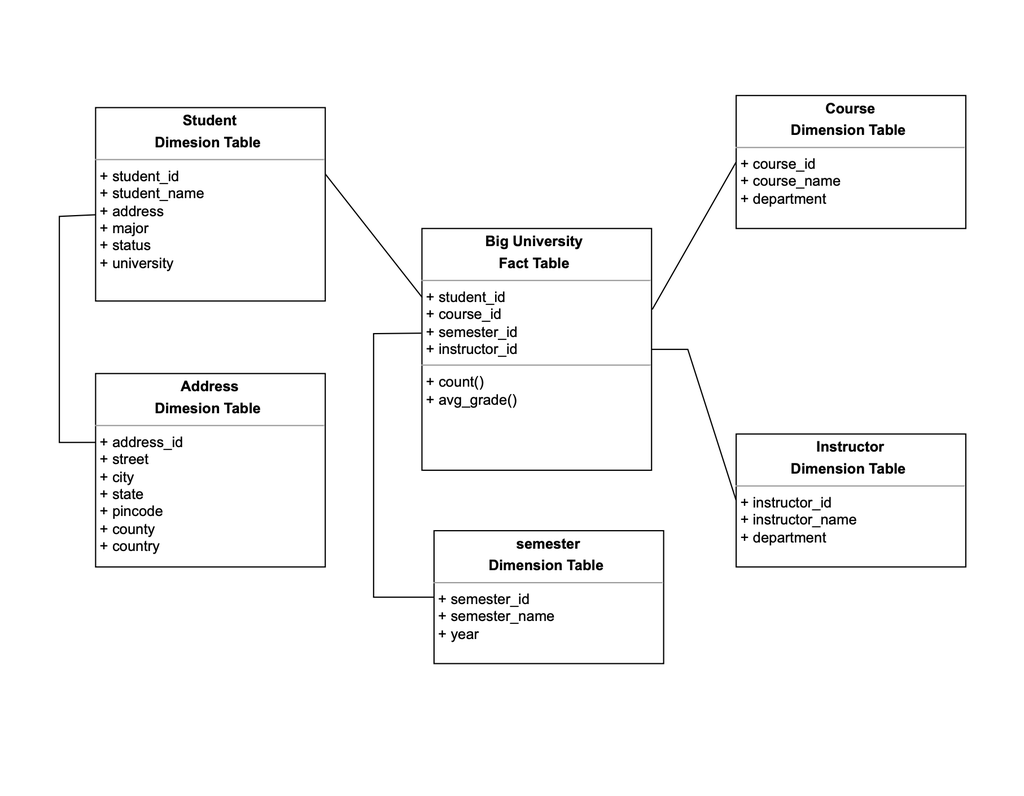

```python
from IPython.display import Image

Image(filename='Snowflake.png',width=800, height=800)
```

2)

### Methods such as following OLAP operation Explaination :

Starting from the base cuboid [student, course, semester, instructor], We can do the following OLAP operations to get the average grade for each Big University student's Computer Science (CS) courses:

#### Method 1 :

Roll-up from Semester to Year: This process adds up the grades for every student and computer science course year by year in order to aggregate the data. We can use this to find the average grade for each year's CS courses.

#### Method 2 :

Drill-down from Year to Semester: If more information is needed, you can carry out the opposite process to drill down to the semester level.

3 )

When there are four dimensions and five levels in each dimension (including "all"), The total number of cuboids—including base and apex cuboids—can be computed as follows:

#### Five levels per dimension multiplied by four equals 625 cuboids.

4 )

```python
df = pd.read_csv('input_DW_data.csv')
df
```

|  | name | course | semester | instructor | avg_grade |
| --- | --- | --- | --- | --- | --- |
| 0 | A | Eng | 1 | X | 76 |
| 1 | B | CS | 1 | Y | 66 |
| 2 | C | CS | 1 | Y | 91 |
| 3 | B | CS | 2 | Z | 57 |
| 4 | C | CS | 2 | Z | 88 |
| 5 | A | Eng | 2 | X | 84 |
| 6 | B | CS | 3 | Y | 51 |
| 7 | A | Eng | 3 | X | 61 |
| 8 | C | CS | 3 | Y | 81 |

```python
engine = create_engine('postgresql://postgres:root@localhost:5432/postgres')

# Storing DataFrame-df into PSQL database
df.to_sql('student_data', engine, if_exists='replace', index=False)
```

```
9
```

5 )

```python
# Read
def read_record(Table, Field, Value, engine):
    query = f"SELECT * FROM {Table} WHERE {Field} = '{Value}'"
    result = engine.execute(query)
    return result.fetchall()

result_df = pd.DataFrame(read_record('student_data', 'course', 'CS', engine))
print("Reading Records:\n\n",result_df)
```

```
Reading Records:

   name course  semester instructor  avg_grade
0    B     CS         1          Y         66
1    C     CS         1          Y         91
2    B     CS         2          Z         57
3    C     CS         2          Z         88
4    B     CS         3          Y         51
5    C     CS         3          Y         81
```

```python
# Write record
def write_record(Table, data_dict, engine):
    # Insert record into the database
    keys = ','.join(data_dict.keys())
    values = ','.join([f"'{value}'" for value in data_dict.values()])
    query = f"INSERT INTO {Table} ({keys}) VALUES ({values})"

    engine.execute(query)

data_to_insert = {
    'name': 'Aakash',
    'course': 'CS',
    'semester': '3',
    'instructor': 'Z',
    'avg_grade': '5'
}
write_record('student_data', data_to_insert, engine)


query = "SELECT * FROM student_data"
result_df = pd.read_sql_query(query, engine)
result_df
```

|  | name | course | semester | instructor | avg_grade |
| --- | --- | --- | --- | --- | --- |
| 0 | A | Eng | 1 | X | 76 |
| 1 | B | CS | 1 | Y | 66 |
| 2 | C | CS | 1 | Y | 91 |
| 3 | B | CS | 2 | Z | 57 |
| 4 | C | CS | 2 | Z | 88 |
| 5 | A | Eng | 2 | X | 84 |
| 6 | B | CS | 3 | Y | 51 |
| 7 | A | Eng | 3 | X | 61 |
| 8 | C | CS | 3 | Y | 81 |
| 9 | Aakash | CS | 3 | Z | 5 |

```python
# Update record
def update_record(engine, table_name, update_data, condition_column, condition_value):
        update_query = f"UPDATE {table_name} SET "
        update_query += ', '.join([f"{column} = '{value}'" for column, value in update_data.items()])
        update_query += f" WHERE {condition_column} = '{condition_value}'"

        engine.execute(update_query)

# Updated Record Value
update_data = {'avg_grade': 20}
condition_column = 'name'
condition_value = 'Aakash'

update_record(engine, 'student_data', update_data, condition_column, condition_value)

query = "SELECT * FROM student_data"
result_df = pd.read_sql_query(query, engine)
result_df
```

|  | name | course | semester | instructor | avg_grade |
| --- | --- | --- | --- | --- | --- |
| 0 | A | Eng | 1 | X | 76 |
| 1 | B | CS | 1 | Y | 66 |
| 2 | C | CS | 1 | Y | 91 |
| 3 | B | CS | 2 | Z | 57 |
| 4 | C | CS | 2 | Z | 88 |
| 5 | A | Eng | 2 | X | 84 |
| 6 | B | CS | 3 | Y | 51 |
| 7 | A | Eng | 3 | X | 61 |
| 8 | C | CS | 3 | Y | 81 |
| 9 | Aakash | CS | 3 | Z | 20 |

```python
# Read Dataset Full
def read_dataset(name, engine):
    query = f"SELECT * FROM {name}"
    df = pd.read_sql(query, engine)
    return df

fulldf = read_dataset('student_data', 'postgresql://postgres:root@localhost:5432/postgres')
fulldf

query = "SELECT * FROM student_data"
result_df = pd.read_sql_query(query, engine)
result_df
```

|  | name | course | semester | instructor | avg_grade |
| --- | --- | --- | --- | --- | --- |
| 0 | A | Eng | 1 | X | 76 |
| 1 | B | CS | 1 | Y | 66 |
| 2 | C | CS | 1 | Y | 91 |
| 3 | B | CS | 2 | Z | 57 |
| 4 | C | CS | 2 | Z | 88 |
| 5 | A | Eng | 2 | X | 84 |
| 6 | B | CS | 3 | Y | 51 |
| 7 | A | Eng | 3 | X | 61 |
| 8 | C | CS | 3 | Y | 81 |
| 9 | Aakash | CS | 3 | Z | 20 |

```python
# Write dataset
def write_dataset(name, dataset, engine):
    dataset.to_sql(name, engine, if_exists='append', index=False)

data_to_write = pd.DataFrame({'name': ['E', 'F'], 'course': ['CS', 'Eng'], 'semester': [1, 2], 'instructor': ['X', 'Y'], 'avg_grade': [75, 88]})
wd = write_dataset('student_data', data_to_write, 'postgresql://postgres:root@localhost:5432/postgres')
wd

query = "SELECT * FROM student_data"
result_df = pd.read_sql_query(query, engine)
result_df
```

|  | name | course | semester | instructor | avg_grade |
| --- | --- | --- | --- | --- | --- |
| 0 | A | Eng | 1 | X | 76 |
| 1 | B | CS | 1 | Y | 66 |
| 2 | C | CS | 1 | Y | 91 |
| 3 | B | CS | 2 | Z | 57 |
| 4 | C | CS | 2 | Z | 88 |
| 5 | A | Eng | 2 | X | 84 |
| 6 | B | CS | 3 | Y | 51 |
| 7 | A | Eng | 3 | X | 61 |
| 8 | C | CS | 3 | Y | 81 |
| 9 | Aakash | CS | 3 | Z | 20 |
| 10 | E | CS | 1 | X | 75 |
| 11 | F | Eng | 2 | Y | 88 |

```python
def list_datasets(engine):
    query = "SELECT table_name FROM information_schema.tables WHERE table_schema = 'public'"
    result = engine.execute(query)
    tables = [row[0] for row in result]
    return tables

table_names = list_datasets(engine)
print("Tables in the database:\n")
for table in table_names:
    print("-",table)
```

```
Tables in the database:

- student_data
- employee_data
```

```python
# This function is used to delete particular table from database
# def delete_table(engine, table_name):
#         delete_query = f"DROP TABLE {table_name}"
#         engine.execute(delete_query)

# delete_table(engine, 'employee_data')
```

# DM-Practical-02 B - Association Rules

### Q1: Transaction Data Cleaning

1)

```python
data = pd.read_excel("Online_Retail.xlsx")
```

```python
data['InvoiceNo'] = data['InvoiceNo'].astype(str)
data = data.dropna(subset=['Description', 'CustomerID'])
data = data[~(data['InvoiceNo'].str.startswith('C') | data['InvoiceNo'].isnull())]
data = data.reset_index(drop=True)
data
```

|  | InvoiceNo | StockCode | Description | Quantity | InvoiceDate | UnitPrice | CustomerID | Country |
| --- | --- | --- | --- | --- | --- | --- | --- | --- |
| 0 | 536365 | 85123A | WHITE HANGING HEART T-LIGHT HOLDER | 6 | 2010-12-01 08:26:00 | 2.55 | 17850.0 | United Kingdom |
| 1 | 536365 | 71053 | WHITE METAL LANTERN | 6 | 2010-12-01 08:26:00 | 3.39 | 17850.0 | United Kingdom |
| 2 | 536365 | 84406B | CREAM CUPID HEARTS COAT HANGER | 8 | 2010-12-01 08:26:00 | 2.75 | 17850.0 | United Kingdom |
| 3 | 536365 | 84029G | KNITTED UNION FLAG HOT WATER BOTTLE | 6 | 2010-12-01 08:26:00 | 3.39 | 17850.0 | United Kingdom |
| 4 | 536365 | 84029E | RED WOOLLY HOTTIE WHITE HEART. | 6 | 2010-12-01 08:26:00 | 3.39 | 17850.0 | United Kingdom |
| ... | ... | ... | ... | ... | ... | ... | ... | ... |
| 397919 | 581587 | 22613 | PACK OF 20 SPACEBOY NAPKINS | 12 | 2011-12-09 12:50:00 | 0.85 | 12680.0 | France |
| 397920 | 581587 | 22899 | CHILDREN'S APRON DOLLY GIRL | 6 | 2011-12-09 12:50:00 | 2.10 | 12680.0 | France |
| 397921 | 581587 | 23254 | CHILDRENS CUTLERY DOLLY GIRL | 4 | 2011-12-09 12:50:00 | 4.15 | 12680.0 | France |
| 397922 | 581587 | 23255 | CHILDRENS CUTLERY CIRCUS PARADE | 4 | 2011-12-09 12:50:00 | 4.15 | 12680.0 | France |
| 397923 | 581587 | 22138 | BAKING SET 9 PIECE RETROSPOT | 3 | 2011-12-09 12:50:00 | 4.95 | 12680.0 | France |

397924 rows × 8 columns

```python
print(data.columns)
```

```
Index(['InvoiceNo', 'StockCode', 'Description', 'Quantity', 'InvoiceDate',
       'UnitPrice', 'CustomerID', 'Country'],
      dtype='object')
```

2)

```python
data = data[data['Description'] != 'POSTAGE']
one_item = data['InvoiceNo'].value_counts() == 1
data = data[~data['InvoiceNo'].isin(one_item[one_item].index)]
data
```

|  | InvoiceNo | StockCode | Description | Quantity | InvoiceDate | UnitPrice | CustomerID | Country |
| --- | --- | --- | --- | --- | --- | --- | --- | --- |
| 0 | 536365 | 85123A | WHITE HANGING HEART T-LIGHT HOLDER | 6 | 2010-12-01 08:26:00 | 2.55 | 17850.0 | United Kingdom |
| 1 | 536365 | 71053 | WHITE METAL LANTERN | 6 | 2010-12-01 08:26:00 | 3.39 | 17850.0 | United Kingdom |
| 2 | 536365 | 84406B | CREAM CUPID HEARTS COAT HANGER | 8 | 2010-12-01 08:26:00 | 2.75 | 17850.0 | United Kingdom |
| 3 | 536365 | 84029G | KNITTED UNION FLAG HOT WATER BOTTLE | 6 | 2010-12-01 08:26:00 | 3.39 | 17850.0 | United Kingdom |
| 4 | 536365 | 84029E | RED WOOLLY HOTTIE WHITE HEART. | 6 | 2010-12-01 08:26:00 | 3.39 | 17850.0 | United Kingdom |
| ... | ... | ... | ... | ... | ... | ... | ... | ... |
| 397919 | 581587 | 22613 | PACK OF 20 SPACEBOY NAPKINS | 12 | 2011-12-09 12:50:00 | 0.85 | 12680.0 | France |
| 397920 | 581587 | 22899 | CHILDREN'S APRON DOLLY GIRL | 6 | 2011-12-09 12:50:00 | 2.10 | 12680.0 | France |
| 397921 | 581587 | 23254 | CHILDRENS CUTLERY DOLLY GIRL | 4 | 2011-12-09 12:50:00 | 4.15 | 12680.0 | France |
| 397922 | 581587 | 23255 | CHILDRENS CUTLERY CIRCUS PARADE | 4 | 2011-12-09 12:50:00 | 4.15 | 12680.0 | France |
| 397923 | 581587 | 22138 | BAKING SET 9 PIECE RETROSPOT | 3 | 2011-12-09 12:50:00 | 4.95 | 12680.0 | France |

395451 rows × 8 columns

```python
# data.to_csv('output_file.csv', index=False)
```

3)

```python
data['InvoiceDate'] = pd.to_datetime(data['InvoiceDate'])
data['InvoiceDay'] = data['InvoiceDate'].dt.date
data['InvoiceNo'] = data.groupby(['CustomerID', 'InvoiceDay'])['InvoiceNo'].transform('first')

item_totals = data.groupby('StockCode')['Quantity'].sum()
data = data[data['StockCode'].isin(item_totals[item_totals >= 1000].index)]
data[['InvoiceNo', 'StockCode', 'Description', 'Quantity', 'InvoiceDate', 'UnitPrice', 'CustomerID', 'Country']]
```

|  | InvoiceNo | StockCode | Description | Quantity | InvoiceDate | UnitPrice | CustomerID | Country |
| --- | --- | --- | --- | --- | --- | --- | --- | --- |
| 0 | 536365 | 85123A | WHITE HANGING HEART T-LIGHT HOLDER | 6 | 2010-12-01 08:26:00 | 2.55 | 17850.0 | United Kingdom |
| 1 | 536365 | 71053 | WHITE METAL LANTERN | 6 | 2010-12-01 08:26:00 | 3.39 | 17850.0 | United Kingdom |
| 2 | 536365 | 84406B | CREAM CUPID HEARTS COAT HANGER | 8 | 2010-12-01 08:26:00 | 2.75 | 17850.0 | United Kingdom |
| 3 | 536365 | 84029G | KNITTED UNION FLAG HOT WATER BOTTLE | 6 | 2010-12-01 08:26:00 | 3.39 | 17850.0 | United Kingdom |
| 4 | 536365 | 84029E | RED WOOLLY HOTTIE WHITE HEART. | 6 | 2010-12-01 08:26:00 | 3.39 | 17850.0 | United Kingdom |
| ... | ... | ... | ... | ... | ... | ... | ... | ... |
| 397918 | 581587 | 23256 | CHILDRENS CUTLERY SPACEBOY | 4 | 2011-12-09 12:50:00 | 4.15 | 12680.0 | France |
| 397919 | 581587 | 22613 | PACK OF 20 SPACEBOY NAPKINS | 12 | 2011-12-09 12:50:00 | 0.85 | 12680.0 | France |
| 397920 | 581587 | 22899 | CHILDREN'S APRON DOLLY GIRL | 6 | 2011-12-09 12:50:00 | 2.10 | 12680.0 | France |
| 397921 | 581587 | 23254 | CHILDRENS CUTLERY DOLLY GIRL | 4 | 2011-12-09 12:50:00 | 4.15 | 12680.0 | France |
| 397923 | 581587 | 22138 | BAKING SET 9 PIECE RETROSPOT | 3 | 2011-12-09 12:50:00 | 4.95 | 12680.0 | France |

297061 rows × 8 columns

4)

```python
countData = data[data['Country'] == 'United Kingdom']
countData

# Count the number of UK records
no_UK_records = len(countData)
print("Number of records related to United Kingdom:", no_UK_records)
```

```
Number of records related to United Kingdom: 265069
```

5)

```python
transactions = countData.groupby(['InvoiceNo', 'StockCode'])['Quantity'].sum().unstack(fill_value=0)
transactions[transactions > 0] = 1
transactions.reset_index(inplace=True)
transactions.set_index('InvoiceNo', inplace=True)
transactions
```

| StockCode InvoiceNo | 10125 | 10133 | 10135 | 11001 | 15034 | 15036 | 15039 | 16008 | 16011 | 16012 | ... | 85099F | 85123A | 85132C | 85184C | 85194S | 85199S | 85230B | 85230E | 85230G | M |
| --- | --- | --- | --- | --- | --- | --- | --- | --- | --- | --- | --- | --- | --- | --- | --- | --- | --- | --- | --- | --- | --- |
| 536365 | 0 | 0 | 0 | 0 | 0 | 0 | 0 | 0 | 0 | 0 | ... | 0 | 1 | 0 | 0 | 0 | 0 | 0 | 0 | 0 | 0 |
| 536367 | 0 | 0 | 0 | 0 | 0 | 0 | 0 | 0 | 0 | 0 | ... | 0 | 0 | 0 | 0 | 0 | 0 | 0 | 0 | 0 | 0 |
| 536376 | 0 | 0 | 0 | 0 | 0 | 0 | 0 | 0 | 0 | 0 | ... | 0 | 0 | 0 | 0 | 0 | 0 | 0 | 0 | 0 | 0 |
| 536378 | 0 | 0 | 0 | 0 | 0 | 0 | 0 | 0 | 0 | 0 | ... | 0 | 0 | 0 | 0 | 0 | 0 | 0 | 0 | 0 | 0 |
| 536381 | 0 | 0 | 0 | 0 | 0 | 0 | 0 | 0 | 0 | 0 | ... | 0 | 0 | 0 | 0 | 0 | 0 | 0 | 0 | 0 | 0 |
| ... | ... | ... | ... | ... | ... | ... | ... | ... | ... | ... | ... | ... | ... | ... | ... | ... | ... | ... | ... | ... | ... |
| 581579 | 0 | 0 | 0 | 0 | 0 | 0 | 0 | 0 | 0 | 0 | ... | 0 | 0 | 0 | 0 | 0 | 0 | 0 | 0 | 0 | 0 |
| 581580 | 0 | 0 | 0 | 0 | 0 | 0 | 0 | 0 | 0 | 0 | ... | 0 | 0 | 0 | 0 | 0 | 0 | 0 | 0 | 0 | 0 |
| 581583 | 0 | 0 | 0 | 0 | 0 | 0 | 0 | 0 | 0 | 0 | ... | 0 | 0 | 0 | 0 | 0 | 0 | 0 | 0 | 0 | 0 |
| 581585 | 0 | 0 | 0 | 0 | 0 | 0 | 0 | 0 | 0 | 0 | ... | 0 | 0 | 0 | 0 | 0 | 0 | 0 | 0 | 0 | 0 |
| 581586 | 0 | 0 | 0 | 0 | 0 | 0 | 0 | 0 | 0 | 0 | ... | 0 | 0 | 0 | 0 | 0 | 0 | 0 | 0 | 0 | 0 |

14244 rows × 1164 columns

### Q2: Frequent Items and Association Rules

1)

```python
# Apriori algorithm min support = 0.02
transactions = transactions.applymap(lambda x: x > 0)
freq_item_apriori = apriori(transactions, min_support=0.02, use_colnames=True)
freq_item_apriori
```

|  | support | itemsets |
| --- | --- | --- |
| 0 | 0.020570 | (15036) |
| 1 | 0.034962 | (20685) |
| 2 | 0.025625 | (20712) |
| 3 | 0.025274 | (20713) |
| 4 | 0.023799 | (20718) |
| ... | ... | ... |
| 328 | 0.020640 | (82482, 85123A) |
| 329 | 0.024361 | (85099B, 85099C) |
| 330 | 0.027731 | (85099F, 85099B) |
| 331 | 0.020500 | (22384, 20725, 20727) |
| 332 | 0.023729 | (22697, 22698, 22699) |

333 rows × 2 columns

2)

```python
# FP-Growth algorithm minimum support = 0.02
freq_item_fpgrowth = fpgrowth(transactions, min_support=0.02, use_colnames=True)
freq_item_fpgrowth
```

|  | support | itemsets |
| --- | --- | --- |
| 0 | 0.129598 | (85123A) |
| 1 | 0.058621 | (82482) |
| 2 | 0.053496 | (82494L) |
| 3 | 0.036858 | (82486) |
| 4 | 0.033909 | (82483) |
| ... | ... | ... |
| 328 | 0.026748 | (23209, 20725) |
| 329 | 0.030609 | (85099B, 23203) |
| 330 | 0.028082 | (23202, 23203) |
| 331 | 0.023308 | (85099B, 23202) |
| 332 | 0.032013 | (23300, 23301) |

333 rows × 2 columns

Apriori Algorithm: 333 frequent itemsets in all were discovered. Single products make up a large portion of the frequent itemsets, indicating that single items are bought regularly.

FP-Growth Algorithm: 333 frequent itemsets in all were discovered. Because of its compact data format, FP-Growth performs better and is more effective when support is reasonably high.

##### Conclusion:

3)

```
Scatter Plot
```

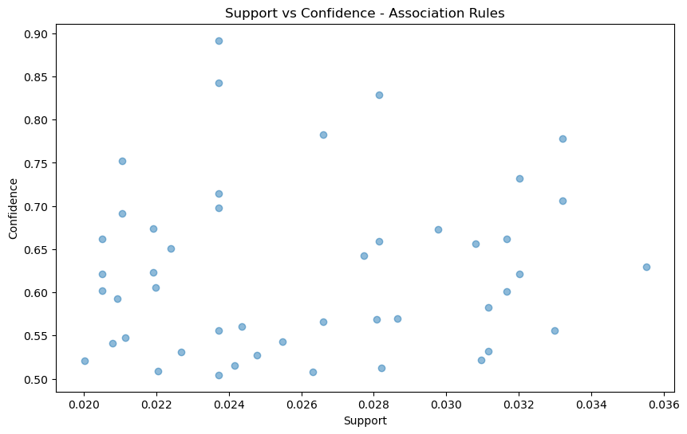

|  | antecedents | consequents | antecedent support | consequent support | support | confidence | lift | leverage | conviction | zhangs_metric |
| --- | --- | --- | --- | --- | --- | --- | --- | --- | --- | --- |
| 0 | (20726) | (20725) | 0.046897 | 0.078489 | 0.025484 | 0.543413 | 6.923414 | 0.021804 | 2.018260 | 0.897660 |
| 1 | (22384) | (20725) | 0.059323 | 0.078489 | 0.032996 | 0.556213 | 7.086492 | 0.028340 | 2.076471 | 0.913052 |
| 2 | (20726) | (22382) | 0.046897 | 0.061008 | 0.024151 | 0.514970 | 8.441005 | 0.021289 | 1.935946 | 0.924906 |
| 3 | (22384) | (20727) | 0.059323 | 0.069363 | 0.030960 | 0.521893 | 7.524141 | 0.026846 | 1.946507 | 0.921777 |
| 4 | (21733) | (85123A) | 0.044229 | 0.129598 | 0.029767 | 0.673016 | 5.193087 | 0.024035 | 2.661908 | 0.844801 |
| 5 | (21928) | (85099B) | 0.035313 | 0.099761 | 0.020921 | 0.592445 | 5.938629 | 0.017398 | 2.208878 | 0.862053 |
| 6 | (21929) | (85099B) | 0.038613 | 0.099761 | 0.021132 | 0.547273 | 5.485822 | 0.017280 | 1.988479 | 0.850554 |
| 7 | (21931) | (85099B) | 0.050267 | 0.099761 | 0.028644 | 0.569832 | 5.711958 | 0.023629 | 2.092763 | 0.868590 |
| 8 | (22910) | (22086) | 0.046967 | 0.065220 | 0.030820 | 0.656203 | 10.061313 | 0.027757 | 2.718989 | 0.944993 |
| 9 | (22662) | (22382) | 0.036296 | 0.061008 | 0.021974 | 0.605416 | 9.923525 | 0.019760 | 2.379700 | 0.933097 |
| 10 | (22386) | (85099B) | 0.056445 | 0.099761 | 0.035524 | 0.629353 | 6.308591 | 0.029893 | 2.428832 | 0.891825 |
| 11 | (22411) | (85099B) | 0.051811 | 0.099761 | 0.026327 | 0.508130 | 5.093459 | 0.021158 | 1.830237 | 0.847584 |
| 12 | (22697) | (22423) | 0.042685 | 0.097164 | 0.022676 | 0.531250 | 5.467576 | 0.018529 | 1.926051 | 0.853536 |
| 13 | (22699) | (22423) | 0.047037 | 0.097164 | 0.024782 | 0.526866 | 5.422453 | 0.020212 | 1.908203 | 0.855838 |
| 14 | (22470) | (22469) | 0.055041 | 0.064589 | 0.028222 | 0.512755 | 7.938787 | 0.024667 | 1.919797 | 0.924946 |
| 15 | (22577) | (22578) | 0.030469 | 0.028012 | 0.021061 | 0.691244 | 24.676900 | 0.020208 | 3.148081 | 0.989629 |
| 16 | (22578) | (22577) | 0.028012 | 0.030469 | 0.021061 | 0.751880 | 24.676900 | 0.020208 | 3.907504 | 0.987127 |
| 17 | (22629) | (22630) | 0.035173 | 0.032505 | 0.021904 | 0.622754 | 19.158780 | 0.020761 | 2.564630 | 0.982357 |
| 18 | (22630) | (22629) | 0.032505 | 0.035173 | 0.021904 | 0.673866 | 19.158780 | 0.020761 | 2.958378 | 0.979648 |
| 19 | (22697) | (22698) | 0.042685 | 0.033979 | 0.028152 | 0.659539 | 19.410083 | 0.026702 | 2.837394 | 0.990771 |
| 20 | (22698) | (22697) | 0.033979 | 0.042685 | 0.028152 | 0.828512 | 19.410083 | 0.026702 | 5.582417 | 0.981843 |
| 21 | (22697) | (22699) | 0.042685 | 0.047037 | 0.033207 | 0.777961 | 16.539209 | 0.031199 | 4.291861 | 0.981430 |
| 22 | (22699) | (22697) | 0.047037 | 0.042685 | 0.033207 | 0.705970 | 16.539209 | 0.031199 | 3.255844 | 0.985912 |
| 23 | (22698) | (22699) | 0.033979 | 0.047037 | 0.026608 | 0.783058 | 16.647576 | 0.025009 | 4.392704 | 0.972993 |
| 24 | (22699) | (22698) | 0.047037 | 0.033979 | 0.026608 | 0.565672 | 16.647576 | 0.025009 | 2.224172 | 0.986325 |
| 25 | (22726) | (22727) | 0.047810 | 0.052654 | 0.031662 | 0.662261 | 12.577668 | 0.029145 | 2.804969 | 0.966712 |
| 26 | (22727) | (22726) | 0.052654 | 0.047810 | 0.031662 | 0.601333 | 12.577668 | 0.029145 | 2.388437 | 0.971655 |
| 27 | (22728) | (22727) | 0.034400 | 0.052654 | 0.022395 | 0.651020 | 12.364180 | 0.020584 | 2.714618 | 0.951866 |
| 28 | (23199) | (85099B) | 0.043316 | 0.099761 | 0.022044 | 0.508914 | 5.101318 | 0.017723 | 1.833159 | 0.840374 |
| 29 | (23202) | (23203) | 0.049354 | 0.068380 | 0.028082 | 0.568990 | 8.321041 | 0.024707 | 2.161482 | 0.925500 |
| 30 | (23208) | (23206) | 0.038402 | 0.052092 | 0.020008 | 0.521024 | 10.001971 | 0.018008 | 1.979029 | 0.935963 |
| 31 | (23208) | (23209) | 0.038402 | 0.062833 | 0.020781 | 0.541133 | 8.612184 | 0.018368 | 2.042351 | 0.919184 |
| 32 | (23300) | (23301) | 0.043738 | 0.051530 | 0.032013 | 0.731942 | 14.204067 | 0.029760 | 3.538303 | 0.972116 |
| 33 | (23301) | (23300) | 0.051530 | 0.043738 | 0.032013 | 0.621253 | 14.204067 | 0.029760 | 2.524808 | 0.980103 |
| 34 | (82482) | (82494L) | 0.058621 | 0.053496 | 0.031171 | 0.531737 | 9.939705 | 0.028035 | 2.021306 | 0.955400 |
| 35 | (82494L) | (82482) | 0.053496 | 0.058621 | 0.031171 | 0.582677 | 9.939705 | 0.028035 | 2.255757 | 0.950227 |
| 36 | (85099C) | (85099B) | 0.043457 | 0.099761 | 0.024361 | 0.560582 | 5.619229 | 0.020026 | 2.048705 | 0.859386 |
| 37 | (85099F) | (85099B) | 0.043176 | 0.099761 | 0.027731 | 0.642276 | 6.438132 | 0.023424 | 2.516576 | 0.882791 |
| 38 | (22384, 20725) | (20727) | 0.032996 | 0.069363 | 0.020500 | 0.621277 | 8.956947 | 0.018211 | 2.457301 | 0.918667 |
| 39 | (22384, 20727) | (20725) | 0.030960 | 0.078489 | 0.020500 | 0.662132 | 8.435958 | 0.018070 | 2.727425 | 0.909622 |
| 40 | (20725, 20727) | (22384) | 0.034049 | 0.059323 | 0.020500 | 0.602062 | 10.148839 | 0.018480 | 2.363877 | 0.933243 |
| 41 | (22697, 22698) | (22699) | 0.028152 | 0.047037 | 0.023729 | 0.842893 | 17.919649 | 0.022405 | 6.065683 | 0.971547 |
| 42 | (22697, 22699) | (22698) | 0.033207 | 0.033979 | 0.023729 | 0.714588 | 21.030140 | 0.022601 | 3.384651 | 0.985163 |
| 43 | (22698, 22699) | (22697) | 0.026608 | 0.042685 | 0.023729 | 0.891821 | 20.893244 | 0.022594 | 8.849330 | 0.978164 |
| 44 | (22697) | (22698, 22699) | 0.042685 | 0.026608 | 0.023729 | 0.555921 | 20.893244 | 0.022594 | 2.191935 | 0.994591 |
| 45 | (22698) | (22697, 22699) | 0.033979 | 0.033207 | 0.023729 | 0.698347 | 21.030140 | 0.022601 | 3.204985 | 0.985951 |
| 46 | (22699) | (22697, 22698) | 0.047037 | 0.028152 | 0.023729 | 0.504478 | 17.919649 | 0.022405 | 1.961259 | 0.990800 |

```python
import pandas as pd
from mlxtend.frequent_patterns import apriori, association_rules
import matplotlib.pyplot as plt

frequent_itemsets_apriori = apriori(transactions, min_support=0.02, use_colnames=True)

association_rules_apriori = association_rules(frequent_itemsets_apriori, metric="confidence", min_threshold=0.5)

print("Scatter Plot")
plt.figure(figsize=(10, 6))
plt.scatter(association_rules_apriori['support'], association_rules_apriori['confidence'], alpha=0.5)
plt.xlabel('Support')
plt.ylabel('Confidence')
plt.title('Support vs Confidence - Association Rules')
plt.show()

association_rules_apriori
```

4)

```python
# Rules - support > 0.028 (2.8%) & confidence > 0.5 (50%)
important_rules = association_rules_apriori[(association_rules_apriori['support'] > 0.028) & (association_rules_apriori['confidence'] > 0.5)]
print("Important Association Rules with Support > 0.028 and Confidence > 0.5 ")
important_rules
```

```
Important Association Rules with Support > 0.028 and Confidence > 0.5
```

|  | antecedents | consequents | antecedent support | consequent support | support | confidence | lift | leverage | conviction | zhangs_metric |
| --- | --- | --- | --- | --- | --- | --- | --- | --- | --- | --- |
| 1 | (22384) | (20725) | 0.059323 | 0.078489 | 0.032996 | 0.556213 | 7.086492 | 0.028340 | 2.076471 | 0.913052 |
| 3 | (22384) | (20727) | 0.059323 | 0.069363 | 0.030960 | 0.521893 | 7.524141 | 0.026846 | 1.946507 | 0.921777 |
| 4 | (21733) | (85123A) | 0.044229 | 0.129598 | 0.029767 | 0.673016 | 5.193087 | 0.024035 | 2.661908 | 0.844801 |
| 7 | (21931) | (85099B) | 0.050267 | 0.099761 | 0.028644 | 0.569832 | 5.711958 | 0.023629 | 2.092763 | 0.868590 |
| 8 | (22910) | (22086) | 0.046967 | 0.065220 | 0.030820 | 0.656203 | 10.061313 | 0.027757 | 2.718989 | 0.944993 |
| 10 | (22386) | (85099B) | 0.056445 | 0.099761 | 0.035524 | 0.629353 | 6.308591 | 0.029893 | 2.428832 | 0.891825 |
| 14 | (22470) | (22469) | 0.055041 | 0.064589 | 0.028222 | 0.512755 | 7.938787 | 0.024667 | 1.919797 | 0.924946 |
| 19 | (22697) | (22698) | 0.042685 | 0.033979 | 0.028152 | 0.659539 | 19.410083 | 0.026702 | 2.837394 | 0.990771 |
| 20 | (22698) | (22697) | 0.033979 | 0.042685 | 0.028152 | 0.828512 | 19.410083 | 0.026702 | 5.582417 | 0.981843 |
| 21 | (22697) | (22699) | 0.042685 | 0.047037 | 0.033207 | 0.777961 | 16.539209 | 0.031199 | 4.291861 | 0.981430 |
| 22 | (22699) | (22697) | 0.047037 | 0.042685 | 0.033207 | 0.705970 | 16.539209 | 0.031199 | 3.255844 | 0.985912 |
| 25 | (22726) | (22727) | 0.047810 | 0.052654 | 0.031662 | 0.662261 | 12.577668 | 0.029145 | 2.804969 | 0.966712 |
| 26 | (22727) | (22726) | 0.052654 | 0.047810 | 0.031662 | 0.601333 | 12.577668 | 0.029145 | 2.388437 | 0.971655 |
| 29 | (23202) | (23203) | 0.049354 | 0.068380 | 0.028082 | 0.568990 | 8.321041 | 0.024707 | 2.161482 | 0.925500 |
| 32 | (23300) | (23301) | 0.043738 | 0.051530 | 0.032013 | 0.731942 | 14.204067 | 0.029760 | 3.538303 | 0.972116 |
| 33 | (23301) | (23300) | 0.051530 | 0.043738 | 0.032013 | 0.621253 | 14.204067 | 0.029760 | 2.524808 | 0.980103 |
| 34 | (82482) | (82494L) | 0.058621 | 0.053496 | 0.031171 | 0.531737 | 9.939705 | 0.028035 | 2.021306 | 0.955400 |
| 35 | (82494L) | (82482) | 0.053496 | 0.058621 | 0.031171 | 0.582677 | 9.939705 | 0.028035 | 2.255757 | 0.950227 |

#### Support:

An itemset, or combination of items, is considered relatively common if its support is 0.028 or greater, meaning it appears in at least 2.8% of all transactions.

#### Confidence:

A confidence level of 0.5 or higher indicates that there is a 50% or greater chance that the consequent item will exist when the antecedent item is present. This suggests a robust correlation.

5)

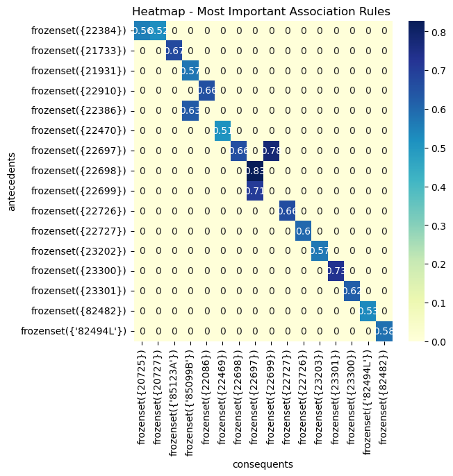

```python
# Heatmap - Most Important Association Rules
pivot_table = important_rules.pivot(index = "antecedents", columns = "consequents", values = "confidence").fillna(0)
plt.figure(figsize=(6,6))

sns.heatmap(pivot_table, annot=True, cmap = "YlGnBu")
plt.title("Heatmap - Most Important Association Rules ")
plt.show()
```